# 第2章 無作為化実験

[R2.1] フィッシャーのp値

作成者：川口康平

最終更新: 2024-09-15

# 1 シミュレーションデータの生成

## 1.1 定数とパラメータの設定

はじめに、シードを固定して、個体数`N`、モンテカルロシミュレーションのドローの数`R`、処置群のサイズ`N_1`を設定する。

```r
set.seed(1)
N <- 1000
R <- 1000
N_1 <- 500
```

つぎに、母集団における平均処置効果`tau_population`を設定する。

```r
tau_population <- 0.2
```

## 1.2 データの生成

以上の定数とパラメーターを元に標本の潜在結果を生成する。この操作が一回の無作為抽出にあたる。無作為抽出された標本における平均処置効果`tau`も計算する。

```r
outcome_potential <-
  tibble::tibble(
    y_0 =
      rnorm(
        N,
        mean = 0,
        sd = 1
      ),
    y_1 =
      rnorm(
        N,
        mean = tau_population,
        sd = 1
      )
  )
tau <-
  outcome_potential %>%
  dplyr::summarise(
    tau = mean(y_1 - y_0)
  ) %>%
  dplyr::pull(tau)

outcome_potential %>%
  head() %>%
  kbl() %>%
  kable_styling()
```

| y_0 | y_1 |
| --- | --- |
| -0.6264538 | 1.3349651 |
| 0.1836433 | 1.3119318 |
| -0.8356286 | -0.6707776 |
| 1.5952808 | 0.4107316 |
| 0.3295078 | 0.2693956 |
| -0.8204684 | -1.4626489 |

```r
outcome_potential %>%
  modelsummary::datasummary_skim()
```

Unique

Missing Pct.

Mean

SD

Min

Median

Max

Histogram

y_0

1000

0

0.0

1.0

-3.0

0.0

3.8

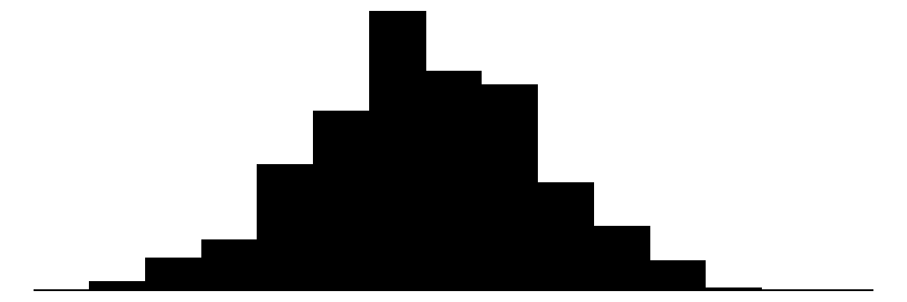

y_1

1000

0

0.2

1.0

-3.1

0.2

3.8

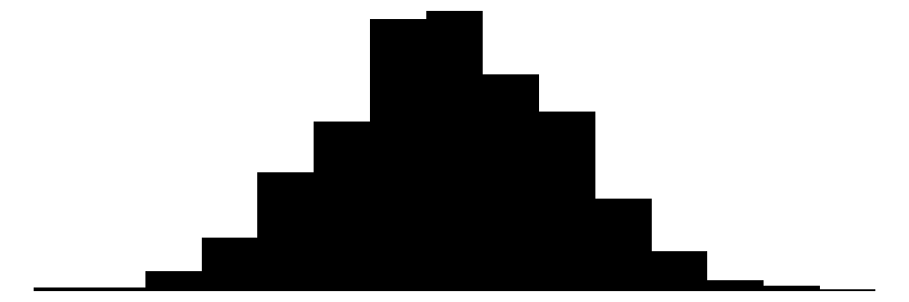

```r
tau
```

```
## [1] 0.1953862
```

```r
data_realized <-
  generate_data_randomized(
    outcome_potential = outcome_potential,
    N_1 = N_1,
    seed = 1
  )
data_realized %>%
  head() %>%
  kbl() %>%
  kable_styling()
```

| z | y |
| --- | --- |
| 1 | 1.3349651 |
| 0 | 0.1836433 |
| 1 | -0.6707776 |
| 0 | 1.5952808 |
| 1 | 0.2693956 |
| 0 | -0.8204684 |

```r
data_realized %>%
  modelsummary::datasummary_skim()
```

Unique

Missing Pct.

Mean

SD

Min

Median

Max

Histogram

z

2

0

0.5

0.5

0.0

0.5

1.0

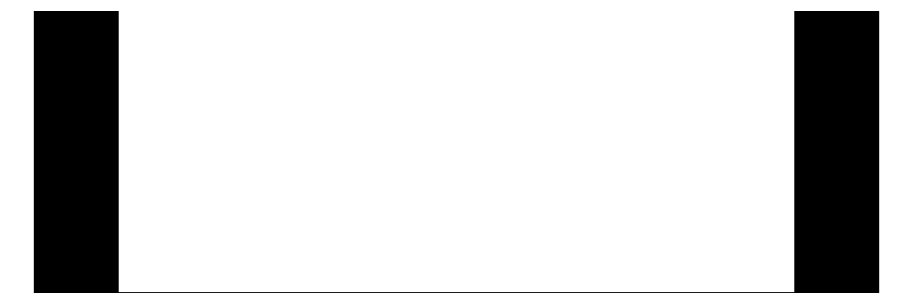

y

1000

0

0.1

1.0

-3.1

0.1

3.8

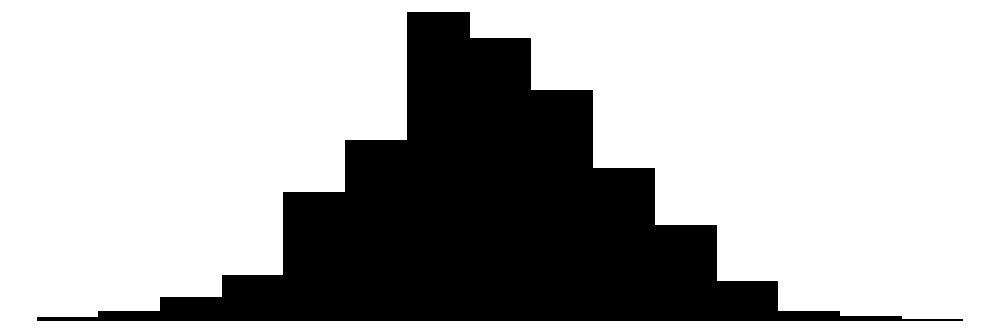

# 2 分析

## 2.1 検定統計量の計算

```r
t <-
  calculate_difference_in_means(
    data_realized = data_realized
  )
t
```

```
## [1] 0.2362761
```

# 3 p値の計算

次に、モンテカルロシミュレーションによってp値を計算する。まず、$Y_i^\ast(1)=Y_i^\ast(0)$という帰無仮説の下で成立する潜在結果のデータフレームを作成して、そのデータフレーム上で処置ベクトルを無作為に割り当てなおすことで検定統計量の分布を推定する。

```r
outcome_potential_null <-
  data_realized %>%
  dplyr::mutate(
    y_0 = y,
    y_1 = y
  )

t_distribution <-
  1:R %>%
  purrr::map(
    .,
    ~ generate_data_randomized(
        outcome_potential = outcome_potential_null,
        N_1 = N_1,
        seed = .
      ) %>%
      calculate_difference_in_means()
  ) %>%
  purrr::reduce(c)

pvalue <-
  mean(
    abs(t_distribution) >
    abs(t)
  )
pvalue
```

```
## [1] 0.001
```

この検定統計量の分布と実現したデータの下での検定統計量の関係は以下のようになっている。

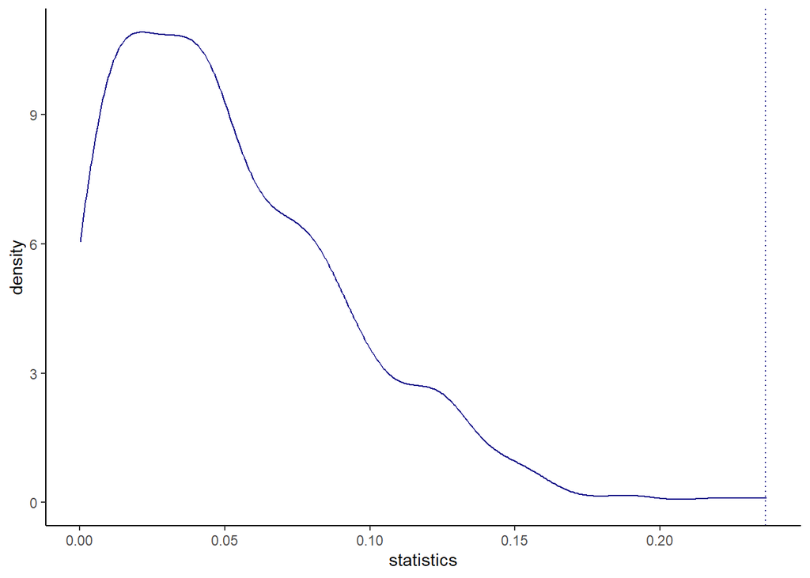